# Schmidt_Emily_TP7

Emily Schmidt

2024-01-06

## 0.1 Libraries

```r
library(fpp3)
library(ggplot2)
library(tsibble)
library(dplyr)
library(scales)
```

# 1 Exercise 2

*Explain what Box-Cox transformation is and when it is applicable.*

A Box Cox transformation is a transformation of non-normal dependent variables into a normal shape. Normality is an important assumption for many statistical techniques; if your data is not normal, applying a Box-Cox means that you are able to run a broader number of tests [1].

**3.1 Transformations and Adjustments**
There are two transformations, logarithms and power, which depend on the parameter $\lambda$ and is defined as follows:
$$w_t =
\begin{cases}
log(y_t) & \text{if $\lambda$ = 0;} \\
(sign(y_t)|y_t|^{\lambda}-1)/\lambda & \text{otherwise.}
\end{cases}$$

This is a modified Box-Cox transformation, allowing for the negative values of $y_t > 0$.

The logarithm is a Box_cox transformation is always a natural logarithm. If $\lambda$ = 0, natural logarithms are used. Otherwise, $\lambda \not= 0$, a power transformation is used follows by some single scaling.

If $\lambda$ = 1, then $w_t = y_t -1$, so the transformed data is shifted downwards but there is no change in the shape of the time series. For all other values of $\lambda$, the time series will change shape.

A good value of $\lambda$ is one which makes the size of the seasonal variation about the same across the whole series, as that makes the forecasting model simpler.

**9.7 ARIMA modelling in fable**  
When fitting an AMIRA model to a set of (non-seasonal) time series data, it may need to be transformed to stabilize the variance, also know as heteroscedasticity. This transformation is used to make the series stationary, which is an assumption of the AMIMA model.

[1] https://www.statisticshowto.com/probability-and-statistics/normal-distributions/box-cox-transformation/

*For the following series, find the appropriate Box-Cox transformation and order of differencing in order to obtain stationary data.*

# 2 Question 1

*Turkish GDP from global_economy.*

## 2.1 Load and Explore Data - global_economy

**Description**: Economic indicators featured by the World Bank from 1960 to 2017.

```
## [1] "tbl_ts"     "tbl_df"     "tbl"        "data.frame"
```

```
## # A tsibble: 6 x 9 [1Y]
## # Key:       Country [1]
##   Country     Code   Year         GDP Growth   CPI Imports Exports Population
##   <fct>       <fct> <dbl>       <dbl>  <dbl> <dbl>   <dbl>   <dbl>      <dbl>
## 1 Afghanistan AFG    1960  537777811.     NA    NA    7.02    4.13    8996351
## 2 Afghanistan AFG    1961  548888896.     NA    NA    8.10    4.45    9166764
## 3 Afghanistan AFG    1962  546666678.     NA    NA    9.35    4.88    9345868
## 4 Afghanistan AFG    1963  751111191.     NA    NA   16.9     9.17    9533954
## 5 Afghanistan AFG    1964  800000044.     NA    NA   18.1     8.89    9731361
## 6 Afghanistan AFG    1965 1006666638.     NA    NA   21.4    11.3     9938414
```

```
## # A tsibble: 15,150 x 9 [1Y]
## # Key:       Country [263]
##    Country     Code   Year         GDP Growth   CPI Imports Exports Population
##    <fct>       <fct> <dbl>       <dbl>  <dbl> <dbl>   <dbl>   <dbl>      <dbl>
##  1 Afghanistan AFG    1960  537777811.     NA    NA    7.02    4.13    8996351
##  2 Afghanistan AFG    1961  548888896.     NA    NA    8.10    4.45    9166764
##  3 Afghanistan AFG    1962  546666678.     NA    NA    9.35    4.88    9345868
##  4 Afghanistan AFG    1963  751111191.     NA    NA   16.9     9.17    9533954
##  5 Afghanistan AFG    1964  800000044.     NA    NA   18.1     8.89    9731361
##  6 Afghanistan AFG    1965 1006666638.     NA    NA   21.4    11.3     9938414
##  7 Afghanistan AFG    1966 1399999967.     NA    NA   18.6     8.57   10152331
##  8 Afghanistan AFG    1967 1673333418.     NA    NA   14.2     6.77   10372630
##  9 Afghanistan AFG    1968 1373333367.     NA    NA   15.2     8.90   10604346
## 10 Afghanistan AFG    1969 1408888922.     NA    NA   15.0    10.1    10854428
## # ℹ 15,140 more rows
```

```
## [1] 1
```

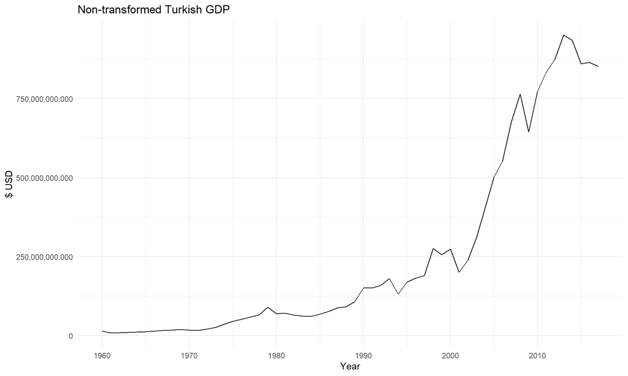

Turkish GDP appears to have trend but no seasonality.

Logarithmic transformations can be utilized to stabilize the variance of a time series, while differencing can stabilize the mean of a time series by eliminating or reducing trend and seasonality, and removing changes in the level of a time series.

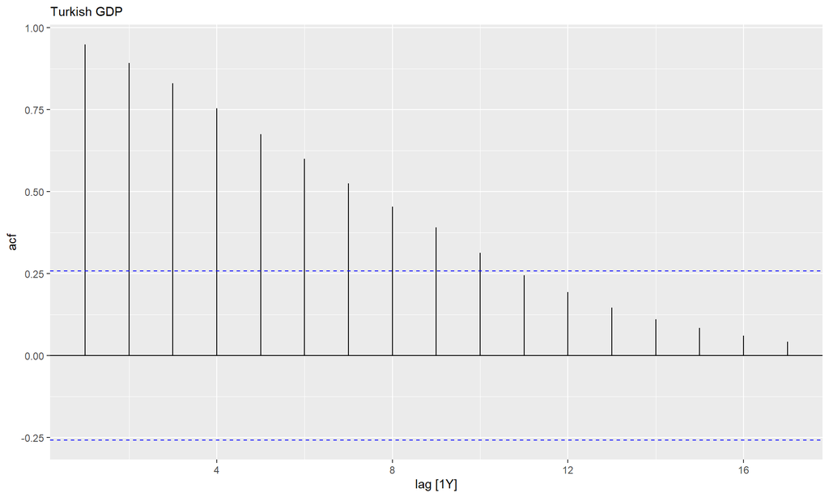

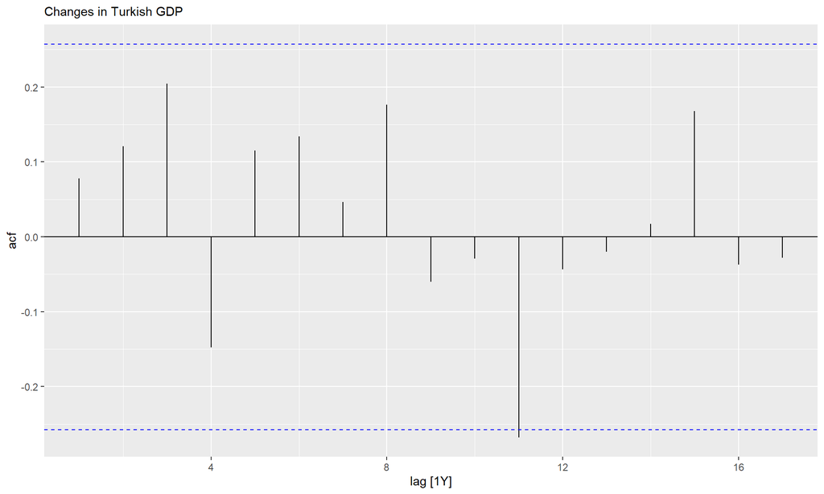

The ACF plot can identify non-stationary time series, as the ACF of stationary data will decrease to zero rapidly, while that of non-stationary data will decline slowly. Additionally, a frequently observed characteristic of non-stationary data is a large, positive value of the first lag, $r_1$. In the first ACF plot, the data slowly approaches zero over time while the difference in GDP hovers around zero. This is one indicator that differencing will need to occur.

```
## # A tibble: 1 × 2
##   lb_stat lb_pvalue
##     <dbl>     <dbl>
## 1    9.88     0.451
```

The ACF plot of the differenced Turkish GDP displays a striking resemblance to that of a white noise series, with only a single autocorrelation outside the 95% limits, and the Ljung-Box Q* statistic yielding a p-value of 0.451 (at $h$ = 10). These findings indicate that the yearly fluctuation in GDP is essentially a random occurrence, unrelated to those of previous years.

## 2.2 Global_economy Lambda

First, find the appropriate lambda for the time series.

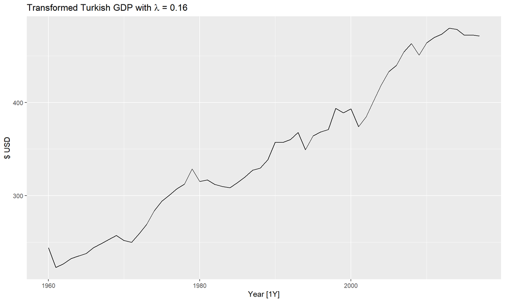

The guerro feature calculates the optimal value of $\lambda$ for Box-Cox transformation by employing the Guerrero method, with a resulting value of 0.16 identified as best choice for this time series.

## 2.3 Global_economy Differencing

To determining whether differencing is necessary, utilize a unit root test. This is a statistical hypothesis test specifically designed to assess stationarity and evaluate the need for differencing.

```
## # A tibble: 1 × 2
##   kpss_stat kpss_pvalue
##       <dbl>       <dbl>
## 1      1.50        0.01
```

The objective of conducting the unit root test is to examine the null hypothesis that the data are stationary, and detect any indications that contradict this assumption. If the resulting p-value < 0.05, it implies that differencing is necessary. In the case of the Turkish GDP, the p-value is 0.01, which leads to the rejection of the null hypothesis.

```
## # A tibble: 1 × 2
##   kpss_stat kpss_pvalue
##       <dbl>       <dbl>
## 1    0.0889         0.1
```

Once we difference the data, the test statistic becomes much smaller, and the range we would expect for stationary data is met by a p-value > 0.05.

To double check that only one difference was needed, we run the following:

```
## # A tibble: 1 × 1
##   ndiffs
##    <int>
## 1      1
```

```
## # A tibble: 1 × 1
##   nsdiffs
##     <int>
## 1       0
```

The process above involves using a sequence of KPSS tests to identify the suitable number of first differences required, which is one. Once lambda is incorporated, no further differencing is needed.

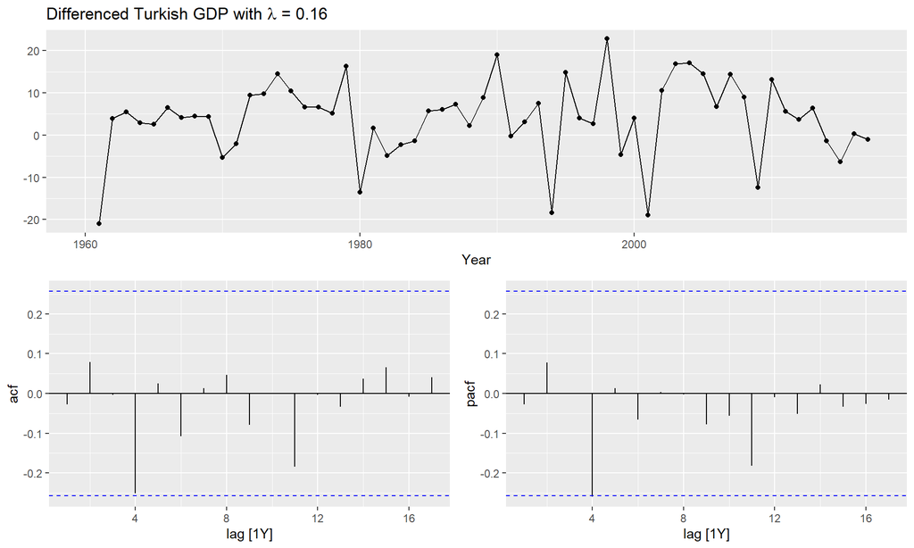

Typically, determining suitable values for $p$ and $q$ based only on a time plot is not feasible. Nonetheless, in some instances, one can leverage the ACF and PACF plots, which are closely connected, to identify appropriate values for $p$ and $q$. $p$ is the order of the autoregressive part while $q$ is the order of the moving average part. After transforming and differencing the time series, both of these plots have lags that remain within the confidence intervals, meaning that those lags are not autocorrelated.

# 3 Question 2

*Accommodation takings in the state of Tasmania from aus_accomodation*

## 3.1 Load and Explore Data - aus_accommodation

**Description**: aus_accommodation is a quarterly ‘tsibble’ containing data on Australian tourist accommodation from short-term non-residential accommodation with 15 or more rooms, 1998 Q1 - 2016 Q2. The data set also contains the Australian Consumer Price Index (CPI) for the same period. Takings are in millions of Australian dollars, Occupancy is a percentage of rooms occupied, CPI is an index with value 100 in 2012 Q1.

```
## [1] "tbl_ts"     "tbl_df"     "tbl"        "data.frame"
```

```
## # A tsibble: 6 x 5 [1Q]
## # Key:       State [1]
##      Date State                        Takings Occupancy   CPI
##     <qtr> <chr>                          <dbl>     <dbl> <dbl>
## 1 1998 Q1 Australian Capital Territory    24.3        65  67
## 2 1998 Q2 Australian Capital Territory    22.3        59  67.4
## 3 1998 Q3 Australian Capital Territory    22.5        58  67.5
## 4 1998 Q4 Australian Capital Territory    24.4        59  67.8
## 5 1999 Q1 Australian Capital Territory    23.7        58  67.8
## 6 1999 Q2 Australian Capital Territory    25.4        61  68.1
```

```
## [1] "Australian Capital Territory" "New South Wales"
## [3] "Northern Territory"           "Queensland"
## [5] "South Australia"              "Tasmania"
## [7] "Victoria"                     "Western Australia"
```

```
## [1] 0
```

```
## # A tsibble: 74 x 2 [1Q]
##       Date Takings
##      <qtr>   <dbl>
##  1 1998 Q1    28.7
##  2 1998 Q2    19.0
##  3 1998 Q3    16.1
##  4 1998 Q4    25.9
##  5 1999 Q1    28.4
##  6 1999 Q2    20.1
##  7 1999 Q3    17.3
##  8 1999 Q4    24.3
##  9 2000 Q1    30.0
## 10 2000 Q2    21.7
## # ℹ 64 more rows
```

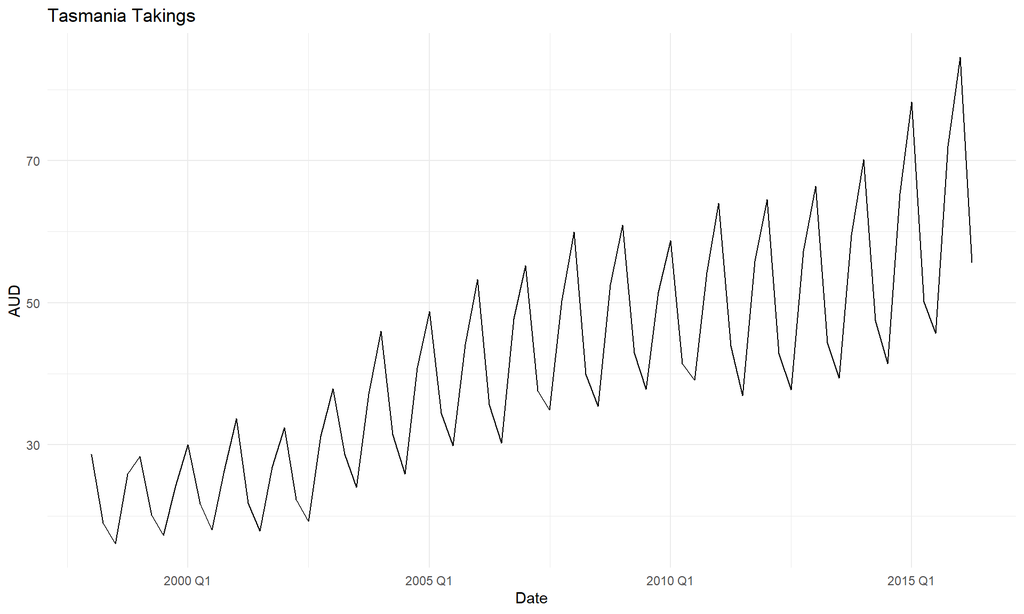

Tasmainia takings appear to have a positive trend and strong seasonality. First, we look at the ACF of the original time series and the difference.

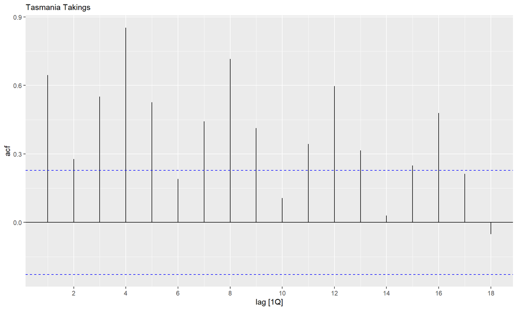

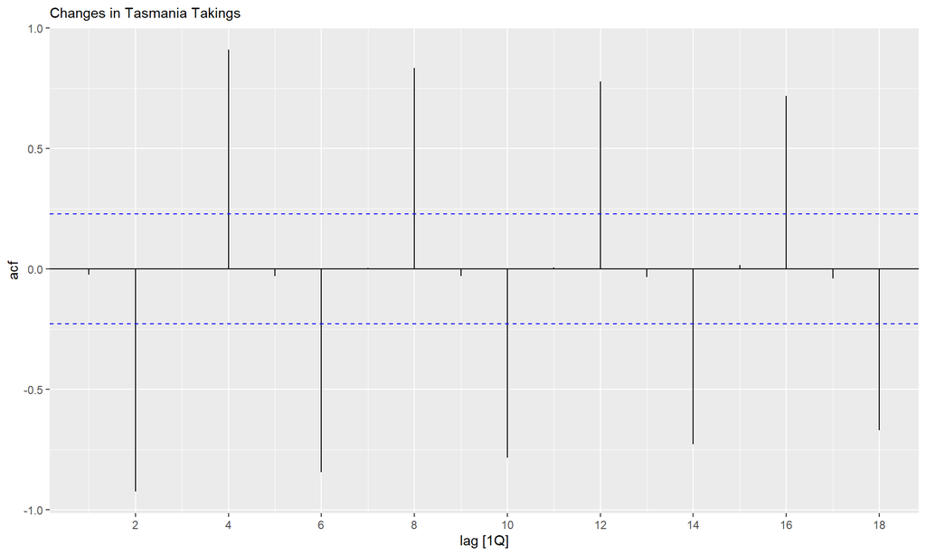

In the first ACF plot, the data slowly approaches zero over time, but the lags are larger or smaller relative to seasonality. The second ACF shows the changes in the takings, the lags are above the 95% confidence interval showing that differencing will need to occur.

```
## # A tibble: 1 × 2
##   lb_stat lb_pvalue
##     <dbl>     <dbl>
## 1    302.         0
```

The ACF plot of the differenced Tasmania takings displays multiple autocorrelations outside the 95% limits, and the Ljung-Box Q* statistic yielding a p-value of 0.0 (at $h$ = 10). These findings indicate that the quarterly fluctuation in takings is not a random occurrence as explained by the seasonality effect.

## 3.2 Aus_accommodation Lambda

First, find the appropriate lambda for the time series.

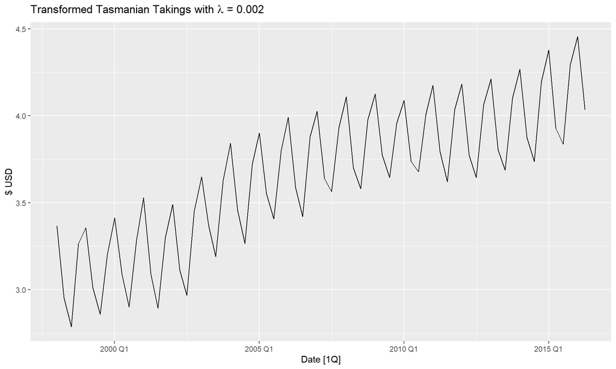

The guerro feature calculates the optimal value of $\lambda$ for Box-Cox transformation by employing the Guerrero method, with a resulting value of 0.002 identified as best choice for this time series.

## 3.3 Aus_accommodation Differencing

Another approach to determining whether differencing is necessary is to utilize a unit root test, which is a statistical hypothesis test specifically designed to assess stationarity and evaluate the need for differencing.

```
## # A tibble: 1 × 2
##   kpss_stat kpss_pvalue
##       <dbl>       <dbl>
## 1      1.85        0.01
```

The objective of conducting the unit root test is to examine the null hypothesis that the data are stationary, and detect any indications that contradict this assumption. If the resulting p-value < 0.05, it implies that differencing is necessary. In the case of the Tasmanian’s Takings, the p-value is 0.01, which leads to the rejection of the null hypothesis.

```
## # A tibble: 1 × 2
##   kpss_stat kpss_pvalue
##       <dbl>       <dbl>
## 1     0.261         0.1
```

Once we difference the data, the test statistic becomes much smaller, and the range we would expect for stationary data is met by a p-value > 0.05.

To double check that only one difference was needed, we run the following:

```
## # A tibble: 1 × 1
##   ndiffs
##    <int>
## 1      1
```

```
## # A tibble: 1 × 1
##   nsdiffs
##     <int>
## 1       0
```

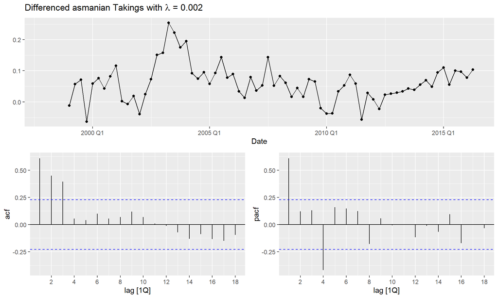

*Note*: Since this is quarterly data, four observations will be removed from the beginning of the time series.

Seasonality continues to impact the ACF plot, but we know from running the unitroot() test either that the time series is now considered stationary since the p-value is greater than 0.05. Upon implementing the requisite changes, we observe that the ACF plot shows roughly three autocorrelations lying beyond the 95% limit, while the PACF plot shows two. This suggests that the data has been made stationary through the transformations.

# 4 Question 3

*Monthly sales from souvenirs*

## 4.1 Load and Explore Data - souvenirs

**Description**: Monthly sales for a souvenir shop on the wharf at a beach resort town in Queensland, Australia.

```
## [1] "tbl_ts"     "tbl_df"     "tbl"        "data.frame"
```

```
## # A tsibble: 6 x 2 [1M]
##      Month Sales
##      <mth> <dbl>
## 1 1987 Jan 1665.
## 2 1987 Feb 2398.
## 3 1987 Mar 2841.
## 4 1987 Apr 3547.
## 5 1987 May 3753.
## 6 1987 Jun 3715.
```

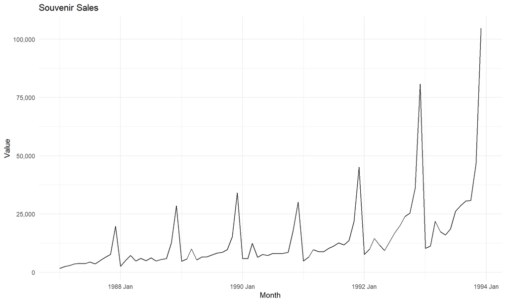

Monthly souvenir sales has an upward trend with multiplicative seasonality, specifically around December.

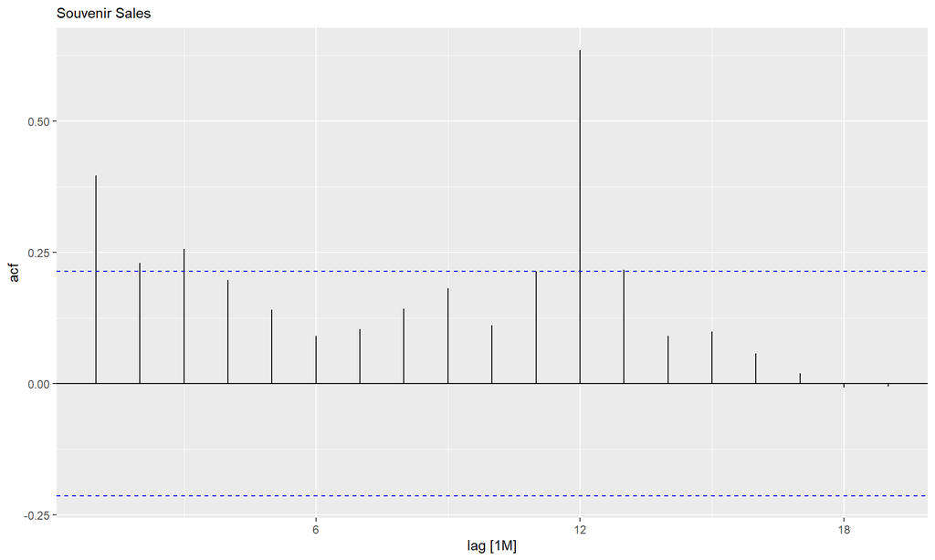

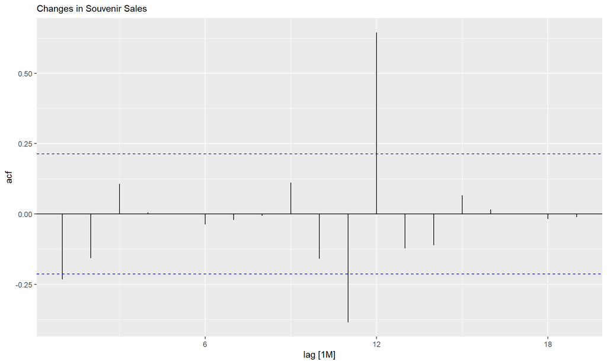

The ACF plot has identified seasonality. In both ACFs, there is a significant spike at 12, which would explain the multiplicative seasonality within the time series.

```
## # A tibble: 1 × 2
##   lb_stat lb_pvalue
##     <dbl>     <dbl>
## 1    11.6     0.311
```

The ACF plot of the differenced souvenir sales yields a p-value of 0.311 (at $h$ = 10). These findings indicate that the monthly fluctuation in sales occurs randomly. Intuitively though, this does not make sense the data’s seasonal effect is visible.

## 4.2 Souvenirs Lambda

First, find the appropriate lambda for the time series.

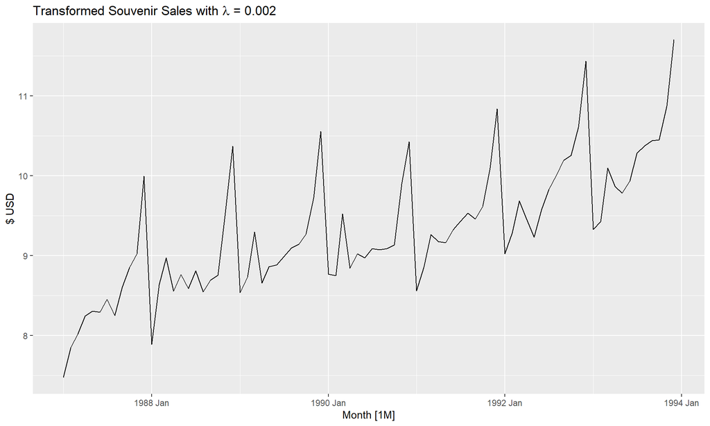

The guerro feature calculates the optimal value of $\lambda$ for Box-Cox transformation by employing the Guerrero method, with a resulting value of 0.002 identified as best choice for this time series. Since this value is very close to 0, it would suggest a natural log transformation.

## 4.3 Souvenirs Differencing

Another approach to determining whether differencing is necessary is to utilize a unit root test, which is a statistical hypothesis test specifically designed to assess stationarity and evaluate the need for differencing.

```
## # A tibble: 1 × 2
##   kpss_stat kpss_pvalue
##       <dbl>       <dbl>
## 1      1.79        0.01
```

The objective of conducting the unit root test is to examine the null hypothesis that the data are stationary, and detect any indications that contradict this assumption. If the resulting p-value < 0.05, it implies that differencing is necessary. In the case of the monthly souvenir sales, the p-value is 0.01, which leads to the rejection of the null hypothesis.

```
## # A tibble: 1 × 2
##   kpss_stat kpss_pvalue
##       <dbl>       <dbl>
## 1    0.0631         0.1
```

Once we difference the data, the test statistic becomes much smaller, and the range we would expect for stationary data is met by a p-value > 0.05.

To double check that only one difference was needed, we run the following:

```
## # A tibble: 1 × 1
##   ndiffs
##    <int>
## 1      1
```

```
## # A tibble: 1 × 1
##   nsdiffs
##     <int>
## 1       0
```

The process above involves using a sequence of KPSS tests to identify the suitable number of first differences required. After the transformation and one differecning has been incorporated, nothing else is needed.

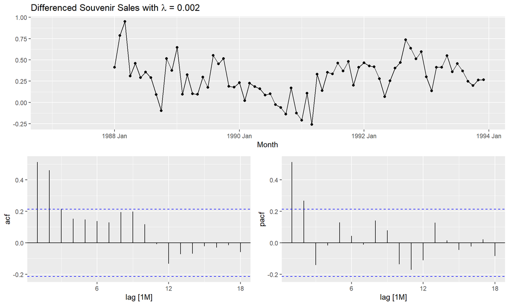

*Note*: Since this is monthly data, 12 observations will be removed from the beginning of the time series.

Upon implementing the requisite changes, we observe from the ACF and PACF charts that only two autocorrelations fall beyond the 95% bounds, indicating that the data has become stationary.

# 5 Exercise 4

Consider aus_airpassengers, the total number of passengers (in millions) from Australian air carriers for the period 1970-2011.

## 5.1 Load and Explore Data - aus_airpassengers

**Description**: Total annual air passengers (in millions) including domestic and international aircraft passengers of air carriers registered in Australia. 1970-2016.

```
## [1] "tbl_ts"     "tbl_df"     "tbl"        "data.frame"
```

```
## # A tsibble: 6 x 2 [1Y]
##    Year Passengers
##   <dbl>      <dbl>
## 1  1970       7.32
## 2  1971       7.33
## 3  1972       7.80
## 4  1973       9.38
## 5  1974      10.7
## 6  1975      11.1
```

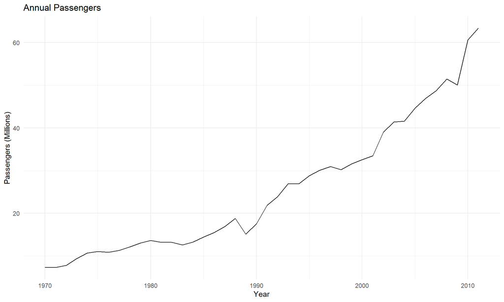

The time series has a positive trend, but does not appear to have seasonality or cycles.

## 5.2 Question 1

*Use ARIMA() to find an appropriate ARIMA model. What model was selected? Check that the residuals look like white noise. Plot forecasts for the next 10 periods.*

```
## Series: Passengers
## Model: ARIMA(0,2,1)
##
## Coefficients:
##           ma1
##       -0.8756
## s.e.   0.0722
##
## sigma^2 estimated as 4.671:  log likelihood=-87.8
## AIC=179.61   AICc=179.93   BIC=182.99
```

$$y_t = -0.88{\epsilon}_{t-1} +
{\epsilon}_t$$

The function ARIMA() automatically chooses the best model. There are two degrees of first differencing involved, and one order of the moving average part, while there is no order of the autoregressive portion. The $\epsilon_t$ is white noise with a standard deviation of 2.16. This specific model, AMIMA(0, 2, 1) only has only parameter, $ma1$ which is the moving average term of order 1. Since it is without a constant, this is a linear exponential smoothing model. This is estimated to be -0.8756. The log likelihood tells you how well the model fits to the data. In terms of the AIC and BIC, the lowest values are preferred. Therefore, since this model was automatically chosen, we would assume these two values are the lowest compared to other models.

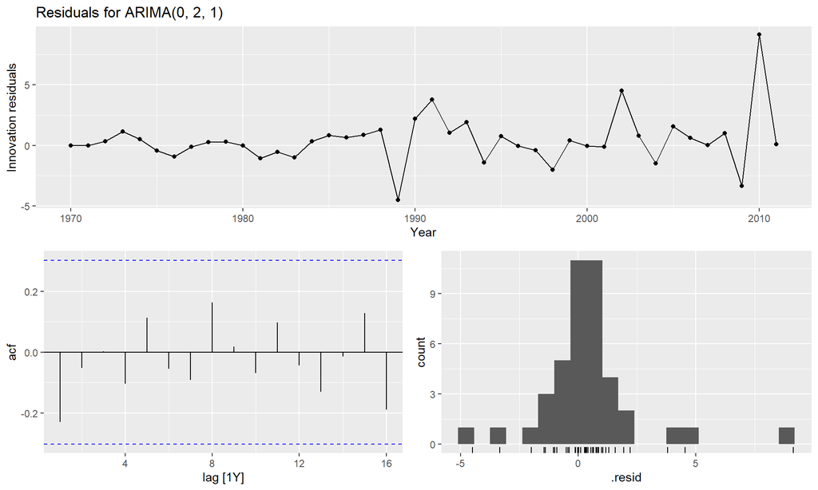

From around 1989 and forward, the time plot shows a slight increase in the variability from the time prior. In addition, the ACF plot demonstrates that the residuals look like white noise as there as no lags above the confidence intervals. The histogram seems to be distributed in a normal manner.

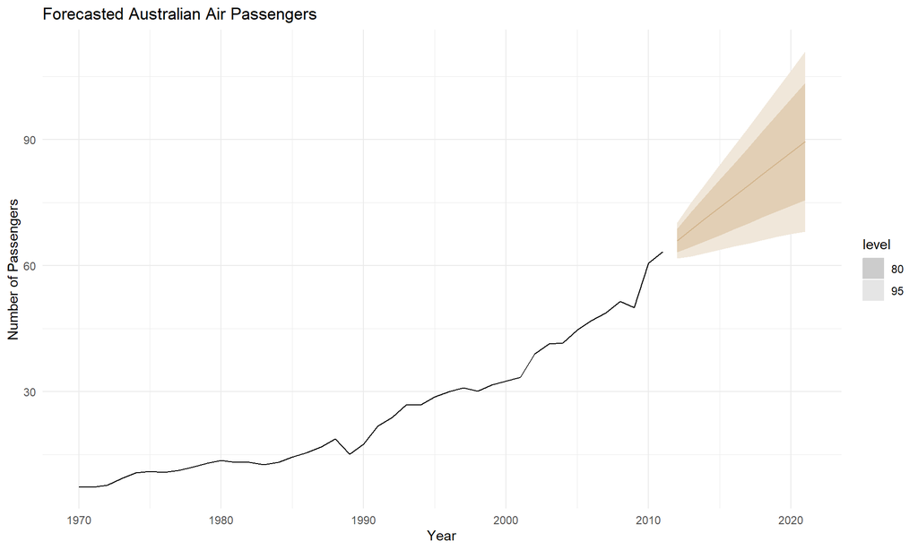

After 2011, the projected trend is positive. The prediction intervals shown are 80% and 95%, which indicates that Australia can expect their passenger numbers to fall within one of those segments with that amount of uncertainty in the forecast.

## 5.3 Question 2

*Write this model in terms of the backshift operator.*

$$ARIMA(0, 2, 1) = (1-B)^dy_t = (1 -
0.88B){\epsilon}_t$$

## 5.4 Question 3

*Plot forecasts from an ARIMA(0,1,0) model with drift and compare these to part 1.*

```
## Series: Passengers
## Model: ARIMA(0,1,0) w/ drift
##
## Coefficients:
##       constant
##         1.3669
## s.e.    0.3319
##
## sigma^2 estimated as 4.629:  log likelihood=-89.08
## AIC=182.17   AICc=182.48   BIC=185.59
```

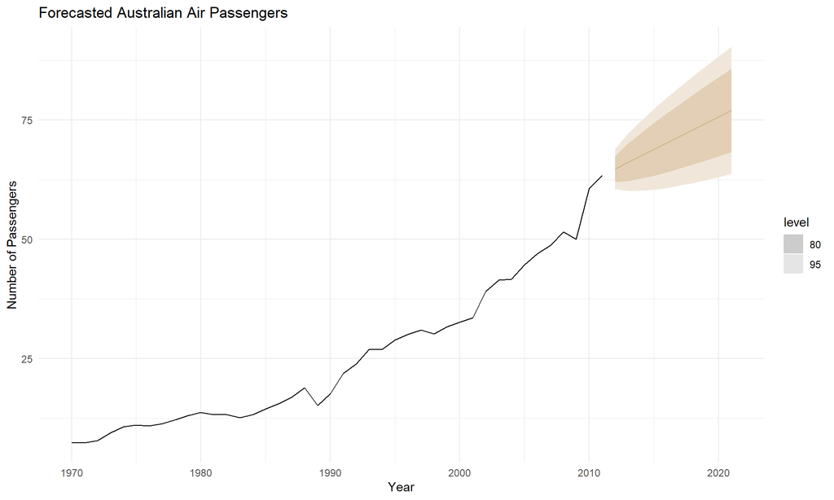

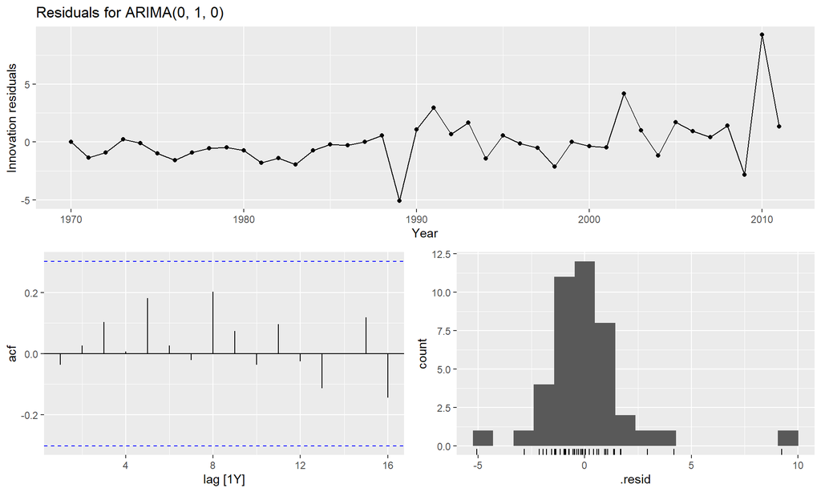

The residuals almost mirror the ARIMA(0, 2, 1) model. The ACF plot remains to demonstrate that the residuals look like white noise as there as no lags above the confidence intervals. The histogram seems to be distributed in a normal manner with less outliers.

## 5.5 Question 4

*Plot forecasts from an ARIMA(2, 1, 2) model with drift and compare these to parts 1 and 3. Remove the constant and see what happens.*

```
## Series: Passengers
## Model: ARIMA(2,1,2) w/ drift
##
## Coefficients:
##          ar1      ar2      ma1     ma2  constant
##       1.4694  -0.5103  -1.5736  0.6780    0.0650
## s.e.  0.3780   0.3558   0.3081  0.2688    0.0294
##
## sigma^2 estimated as 4.748:  log likelihood=-87.74
## AIC=187.47   AICc=189.94   BIC=197.75
```

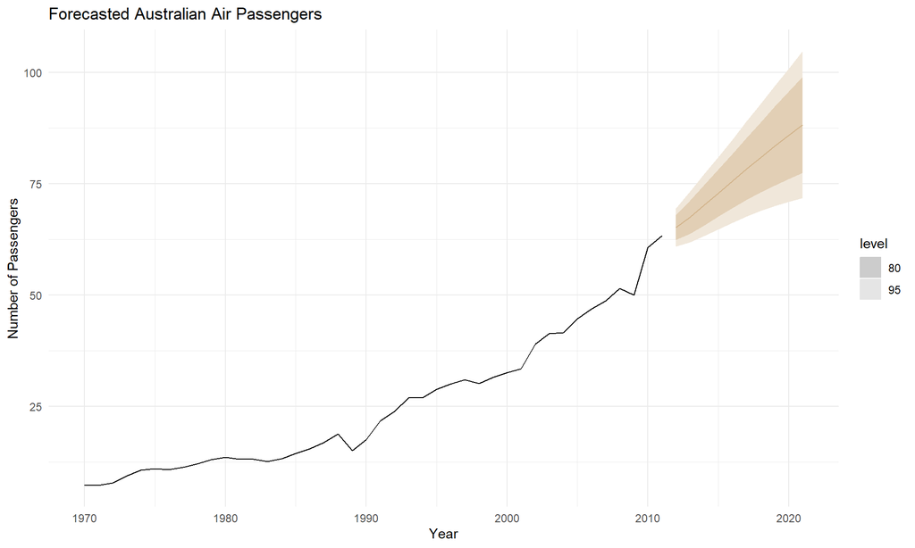

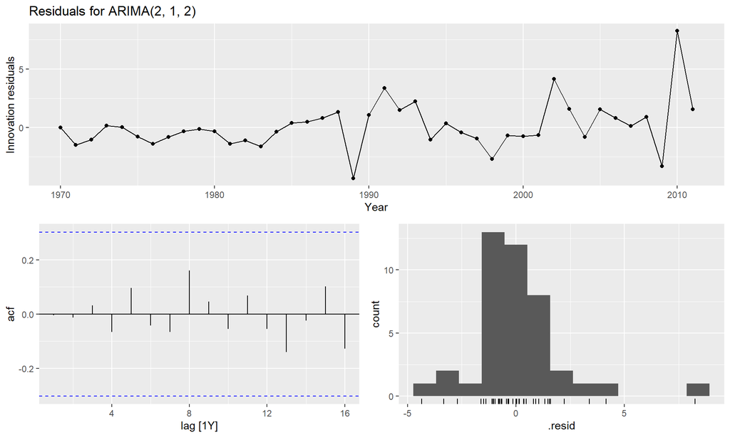

The same story continues with the residuals. There are no lags that exceed the confidence intervals and the histogram appears to be normally distributed.

```
## Series: Passengers
## Model: NULL model
## NULL model
```

When the constant is removed, an error message is given which gives a NULL model.

## 5.6 Question 5

*Plot forecasts from an ARIMA(0, 2, 1) model with a constant. What happens?*

```
## Series: Passengers
## Model: ARIMA(0,2,1) w/ poly
##
## Coefficients:
##           ma1  constant
##       -1.0000    0.0721
## s.e.   0.0709    0.0260
##
## sigma^2 estimated as 4.086:  log likelihood=-85.74
## AIC=177.48   AICc=178.15   BIC=182.55
```

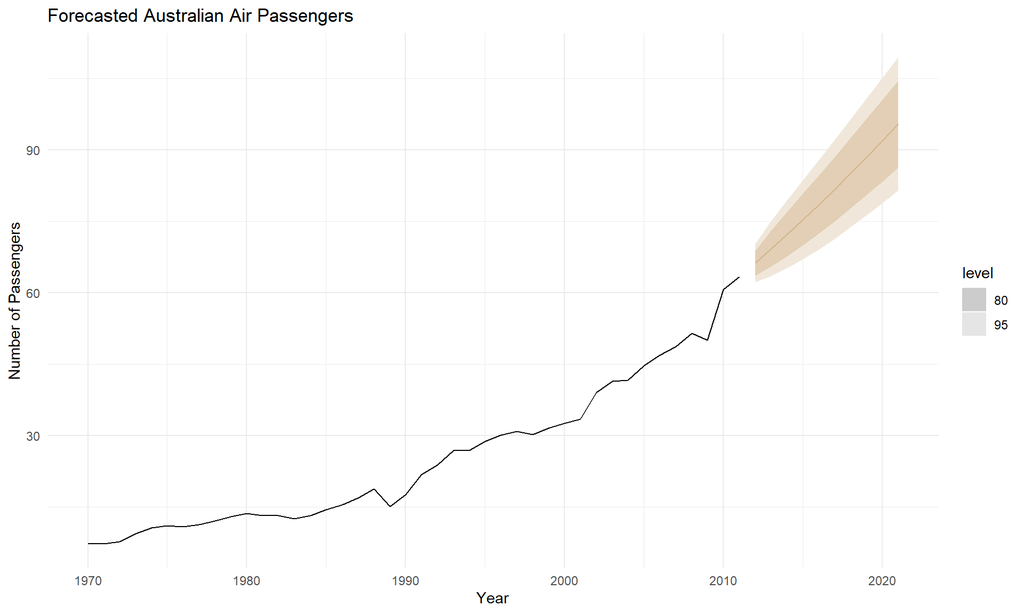

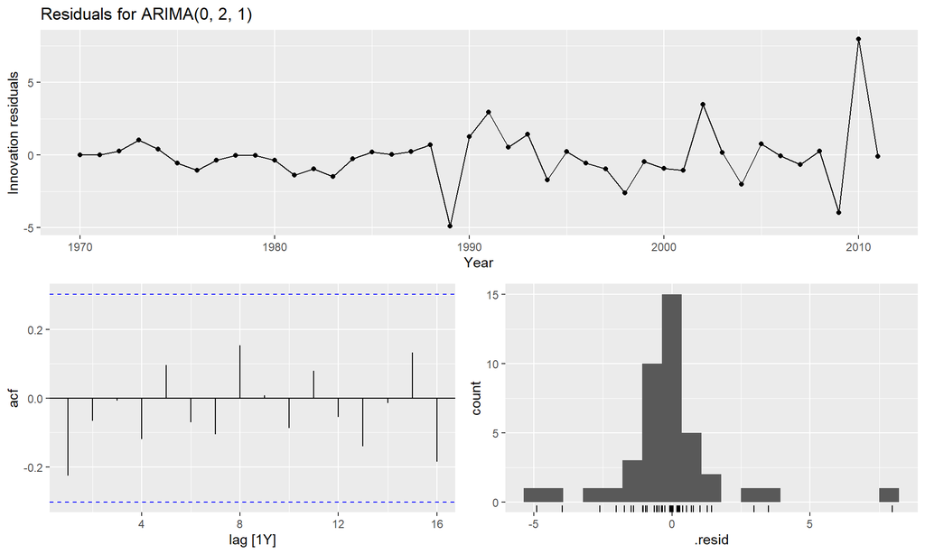

For the same time period around 1989 and forward, the innovation residuals time plot shows a dip but then the residuals seem to slightly increase with their larger variations. The ACF plot shows that the residuals have white noise. The histogram seems to be skewed to the right and is not as well distributed like other models.